# RayCast

# Raycasts detect bodies along a line in 3D space

The `RayCast` node is essential for many 3D interactions, checking if one object can see another, firing fast projectiles, detecting walls, edges of platforms, and vision for AI.

The `RayCast` draws a straight line from one point in space to another. Then the ray can tell you:

- If the line collides with anything.
- The first object encountered.
- The point where the collision occurs.

In this guide, you will learn how to:

- Detect the player with a turret.
- Sense the edge of platforms.
- Detect walls for enemy navigation.
- Detect ledges of platforms for climbing.
- Fire laser beams and bullets.

Contents:

- Setting up a Raycast
- Raycast’s key features
  - Controlling what your ray can detect
  - Collision functions
  - Collision point functions
  - Getting up to date collision information
- How to use a Raycast in practice
  - Turret line of sight
  - Turret line of sight with extra rays
  - Detecting platform edges
  - Enemy pathfinding
  - Climbing ledges
  - Laser beams
  - Hit-scan bullets
- Your questions
  - How can I check how close a ray is to pointing at something?
  - Reacting to certain collisions

## Setting up a Raycast

The first step when setting up a `RayCast` is defining in what direction to point the ray. The `cast_to` property is a `Vector3` representing a local point to draw the ray from its current position.

**Note:** In Godot, the negative z-axis points straight forwards from the current node.

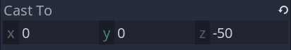

The other essential step is enabling the `RayCast`. By default, rays are disabled, so toggle the *Enabled* property for the ray to update every frame.

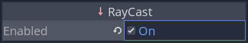

## Raycast’s key features

### Controlling what your ray can detect

There are a few dedicated properties specifically for controlling what *Nodes* the ray can collide with:

- `collide_with_areas`.
- `collide_with_bodies`.

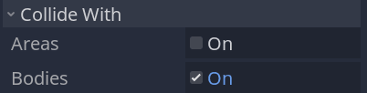

Both of these properties are an effective way to quickly ensure your ray only collides with areas, physics entities, or both.

Then, you can set the mask for the physics layer you want the ray to detect.

**Note:** It doesn’t have a layer property as other entities can’t detect the ray itself.

### Collision functions

The core of a `RayCast` is its ability to find the first body it collides with when cast in the direction of its `cast_to` property.

The `is_colliding()` function does what it says on the tin: if the ray is colliding with a body, it returns `true`; otherwise, `false`.

This function is essential for checking if a body is in contact with a surface, ledge, or wall.

It is also helpful for deciding whether or not to show UI elements like interact buttons when looking at an interactive object.

The `get_collider()` function returns the node a ray collides with.

You can use it to check whether something is an enemy, wall, friendly player, or anything else where you want to check if the ray has detected a specific node or call functions on the node in question.

Typically, you would check information about the node by checking its type, whether it is in a certain group or has a specific method.

### Collision point functions

The ray can also help find information about where the ray collides with its target, for example, if you want to spawn some particles at a shot location or apply a decal like a bullet hole.

For this, there are two handy functions:

1. `get_collision_point()`: this returns the global position of the point the ray intersects its collider.
2. `get_collision_normal()`: this returns the normal (a line straight out from the surface of the collision). The normal is ideal for angling particles or decals to a surface.

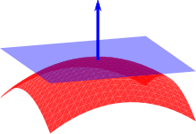

### Getting up to date collision information

The `RayCast` updates once every physics frame. However, if you change where the ray is cast, with its `cast_to` property, or change its transform, this information doesn’t update until the next frame. To manually update the collision information of a ray, you can use the `force_raycast_update()` function.

## How to use a Raycast in practice

### Turret line of sight

Knowing whether an enemy has a direct line of sight to the player is a common need in various games, from security cameras to turrets and any enemy weapons.

[figure not shown]

*Game: Portal 2 (2011)*

The `RayCast` is perfect for the job. We can point a turret straight at the player and check if an attached ray collides with them. If so, they are visible!

We have a turret with a reference to the player. This reference lets us use the `look_at()` function to point towards the player every frame.

```
var is_targetting := false setget set_is_targetting
onready var targetting_position := global_transform.origin + Vector3.FORWARD

onready var _player: Player3D = get_node_or_null(player_path)
onready var _raycast: RayCast = $RayCast
onready var _turret_center: Spatial = $Turret/turret_base/turret_housing/turret_center
onready var _turret_cannon: Spatial = $Turret/turret_base/turret_housing/turret_center/turret_cannon
onready var _player_animator: AnimationPlayer = _player.get_node("TargetAnimation")
onready var _turret_animator: AnimationPlayer = $Turret/AnimationPlayer
```

This turret has a ray that can move independently as well as the actual mesh.

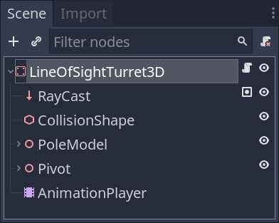

We have a Boolean variable that keeps track of if our turret can see the player.

If the ray is colliding, we can check if the collider was the player. We use the logical `and` operator to check the values in order and tell us if both are true. We do this because if it didn’t check the object was colliding first, trying to get the collider would throw an error.

```
func _process(_delta: float) -> void:
    # Adding a 1 unit vector offset to the player position, since the player's origin is at the ground
    var target_position: Vector3 = _player.global_transform.origin + Vector3.UP
    _raycast.look_at(target_position, Vector3.UP)

    var does_see_player: bool = _raycast.is_colliding() and _raycast.get_collider() == _player
    set_is_targetting(does_see_player)
```

Now that we know if the turret can see the player, we can play some animations. We do this in a `set_is_targetting()` function we have defined. This function plays an animation if the visibility of the player has changed since the last frame. It either shows or hides the warning lights on the turret and an aiming reticle on the player.

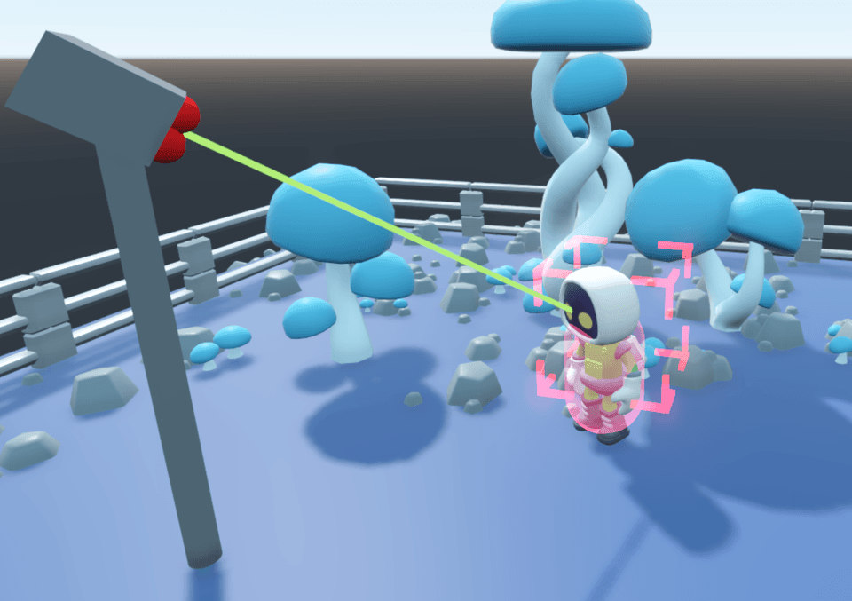

```
func set_is_targetting(value: bool) -> void:
    if value != is_targetting:
        is_targetting = value
        if is_targetting:
            _player_animator.play("highlight")
            _turret_animator.play("armed")
        else:
            _player_animator.play_backwards("highlight")
            _turret_animator.play_backwards("armed")
```

If the ray can see the player, we rotate the turret towards the player with a steering equation.

```
    if is_targetting:
        var steering := target_position - targetting_position
        targetting_position += steering / DRAG_FACTOR
        var direction = _turret_center.global_transform.origin.direction_to(targetting_position)

        var turret_z_axis = Vector3(direction.x, 0.0, direction.z).normalized()
        var turret_x_axis = turret_z_axis.cross(Vector3.UP).normalized()
        _turret_center.transform.basis = Basis(turret_x_axis, Vector3.UP, turret_z_axis)

        var turret_cannon_x_axis = direction.cross(Vector3.UP).normalized()
        var turret_cannot_y_axis = direction.cross(turret_cannon_x_axis).normalized()
        _turret_cannon.global_transform.basis = Basis(turret_cannon_x_axis, turret_cannot_y_axis, direction)
```

One major drawback is that if something is directly between the turret and the player, it thinks its view is obscured even if it could technically see around the edges. The following section addresses this directly.

### Turret line of sight with extra rays

To get around partially obstructed views with our turret, we can take advantage of how cheap performance-wise `RayCast` checks are.

We can define how many rays we want to cast and the horizontal and vertical angles over which to spread them.

```
export var horizontal_ray_count := 2
export var vertical_ray_count := 2
export var horizontal_angle_interval_degrees := 2.5
export var vertical_angle_interval_degrees := 2.5
```

When we create the turret, we can loop over these values and create that many rays in an area at evenly spread angles.

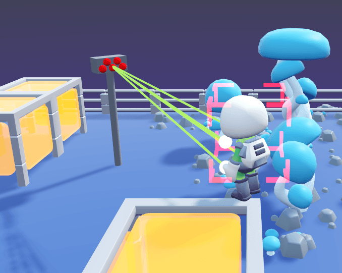

```
func generate_raycast_nodes() -> void:
    for vertical_layer in vertical_ray_count:
        for horizontal_layer in horizontal_ray_count:
            var ray := RayCast.new()
            # We rotate every ray based on our interval to center them on the player.
            #
            # We first want to remap our layer index to center the values on 0.
            # The range_lerp() function remaps a value from one range (the
            # second and third arguments) to another (the last two arguments).
            ray.add_exception(self)
            var horizontal_multiplier := range_lerp(
                horizontal_layer,
                0.0,
                horizontal_ray_count,
                -horizontal_ray_count / 2.0,
                horizontal_ray_count / 2.0 + 1.0
            )
            var vertical_multiplier := range_lerp(
                vertical_layer,
                0.0,
                vertical_ray_count,
                -vertical_ray_count / 2.0,
                vertical_ray_count / 2.0 + 1.0
            )
            # Then, we multiply the angular interval by our multipliers.
            ray.rotate_y(deg2rad(horizontal_angle_interval_degrees) * horizontal_multiplier)
            ray.rotate_x(deg2rad(vertical_angle_interval_degrees) * vertical_multiplier)
            ray.cast_to.z = -ray_length
            ray.collision_mask = 3
            ray.enabled = true

            var debug = DebugDrawRayCast.new()
            ray.add_child(debug)
            _raycast_pivot.add_child(ray)
```

The only other change we need to make is to add a function to check if any of our rays can see the player. We loop over all the children of the node we added the rays to and check if their collider is the player and return `true`. Otherwise, after looping over all of the rays, if none collide with the player, the function returns `false`.

This approach works because the return operation exits the current function. As soon as one ray detects the player, the function stops running, and we don’t check the rest of the rays.

```
func does_see_player() -> bool:
    for ray in _raycast_pivot.get_children():
        if ray.is_colliding() and ray.get_collider().is_in_group("player"):
            return true
    return false
```

And now, our turret is much more resilient to objects obscuring our view.

### Detecting platform edges

A `RayCast` is excellent for simple platform edge detection. Say you want an enemy to patrol a platform but turn around when they reach an edge to avoid falling off - or if you want a player to stay on a platform.

We can add a ray in front of our character, pointing downwards to detect flooring directly in front of our character. Then provided our character can only move in a direction if facing that way, we can stop motion when that ray isn’t colliding.

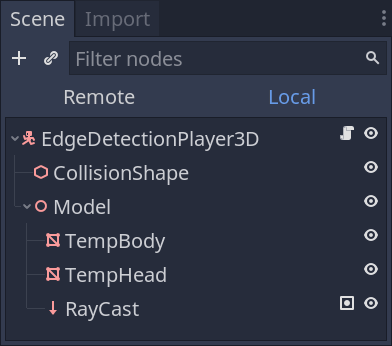

```
onready var _raycast: RayCast = $AstronautSkin/RayCast
```

So our steps are as follows:

- Get the input from the player to figure out what direction they want to move in.
- Align the character model and ray to that direction.
- If the ray is colliding, apply motion in that direction.
- If it isn’t colliding, stop the motion.

Because we update the model’s orientation before moving, the player can move away from the platform edge even though the ray isn’t colliding.

```
    _move_direction = _get_camera_oriented_input()

    # To not orient quickly to the last input, we save a last strong direction,
    # this also ensures a good normalized value for the rotation basis.
    if _move_direction.length() > 0.2:
        _last_strong_direction = _move_direction.normalized()

    _orient_character_to_direction(_last_strong_direction, delta)

    _velocity = _velocity.linear_interpolate(_move_direction * move_speed, acceleration * delta)
    if not _raycast.is_colliding():
        _velocity = Vector3.ZERO

    _velocity = move_and_slide_with_snap(
        _velocity, _snap, Vector3.UP, do_stop_on_slope, 4, deg2rad(45), has_infinite_inertia
    )
```

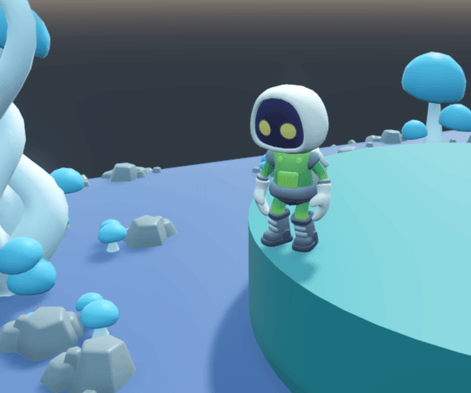

### Enemy pathfinding

Many games have simple AI/ enemies that can move and explore freely. Using *Rays*, you can add simple wall detection to your AI, allowing them to avoid obstacles and move in a way that seems to have a sense of their surroundings.

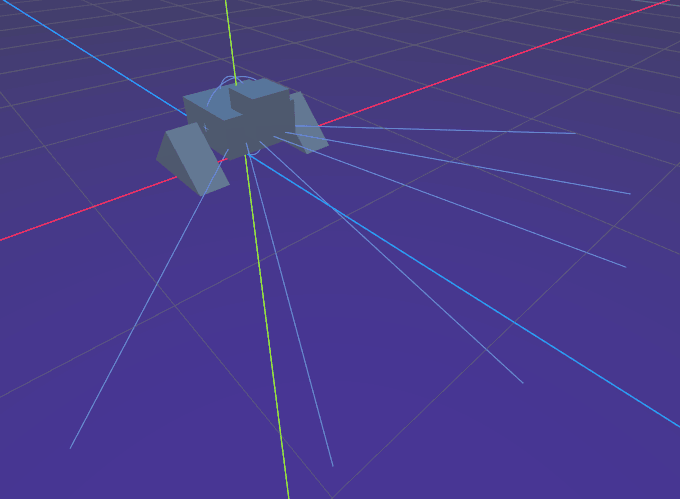

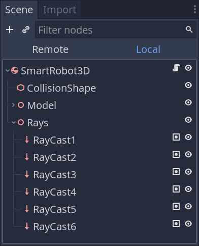

This pathfinding requires relatively little code, but you need to fiddle with physics properties until the AI behaves as expected. Getting its speed and turning speed into reasonable bounds takes some trial and error.

```
var move_force := 25.0
var turn_force := 4.0
var direction := Vector3.FORWARD
var _velocity := Vector3.ZERO

onready var _rays := $Rays.get_children()
```

Our body tries to move straight forwards. A cone of rays spanning from left to right in front detects walls. If these rays collide, we can apply torque in the opposite direction, which rotates our character to move away from the obstacle.

If we apply torque like this for each colliding ray, our character steers away from larger and closer objects faster as more rays collide.

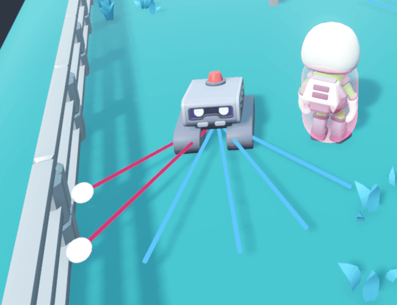

```
func _integrate_forces(state: PhysicsDirectBodyState) -> void:
    state.apply_central_impulse(global_transform.basis.z * move_force * state.step)

    var torque := Vector3.ZERO
    var is_colliding := false
    for ray in _rays:
        var raycast := ray as RayCast
        if raycast.is_colliding():
            is_colliding = true
            var magnitude := calculate_collision_magnitude(raycast)
            torque += Vector3.DOWN * raycast.cast_to.x * magnitude * turn_force * state.step

    # To avoid getting stuck we apply force in one direction if the torque is
    # close to even after colliding
    if is_colliding and abs(torque.y) < 0.01:
        torque.y = turn_force * state.step
    state.apply_torque_impulse(torque)
```

### Climbing ledges

Many games allow the player to climb and mantle ledges to afford more opportunities in combat and exploration. Action platformers like *Tomb Raider* and *Ratchet and Clank* take advantage of climbing like this for exploration.

[figure not shown]

*Game: Tomb Raider Legend (2006)*

There are many ways you could approach the problem of figuring out if a player can climb a wall, but one of the most straightforward implementations is using multiple `RayCast` nodes.

**Note:** Mantling and climbing animations can be very complex when it comes to implementing associated animations and relative motion and updating the player and camera position. This guide only covers the topic of detecting ledge hanging and changing states.

```
onready var _body_raycast: RayCast = $Pivot/BodyRayCast
onready var _reach_raycast: RayCast = $Pivot/ReachRayCast
onready var _ledge_timer: Timer = $LedgeTimer
```

Our player has two `RayCast` nodes. One at the height where the body hangs onto a ledge, the second is `0.05` units above. This lets us detect when our body is in contact with a ledge, as the following three conditions are met:

- The player is not on the floor.
- Our lower `RayCast` is colliding with the ledge.
- Our upper `RayCast` isn’t colliding with anything as there is open space above the ledge.

[figure not shown]

We group these checks into a function called `is_ledge_hanging()`, and we check this state at the start of our `physics_process()` function.

```
func is_ledge_hanging() -> bool:
    return (
        not is_on_floor()
        and _body_raycast.is_colliding()
        and not _reach_raycast.is_colliding()
        and _ledge_timer.is_stopped()
    )
```

The variable that stores this state has a setter method so that when we start hanging for the first time, we can play an animation then transition to idle when we stop hanging.

```
var is_on_ledge := false setget set_is_on_ledge

func set_is_on_ledge(on_ledge: bool) -> void:
    var was_on_ledge := is_on_ledge
    is_on_ledge = on_ledge

    if on_ledge and not was_on_ledge:
        _playback.travel("ledge")
        _skeleton.clear_bones_global_pose_override()

    elif was_on_ledge and not on_ledge:
        _playback.travel("idle")
        # Only the ledge animations use root motion so we need to reset the
        # bone's position to its rest pose.
        _skeleton.set_bone_global_pose_override(ROOT_BONE_INDEX, Transform.IDENTITY, 1.0, true)
        transform.origin = Vector3.ZERO
```

We can make the player shimmy along the ledge if they are hanging by making left and right inputs relative to the hanging player.

[figure not shown]

```
    if is_ledge_hanging():
        _move_direction = _calculate_ledge_oriented_input()
        update_last_strong_direction()
        var wall_direction = -_body_raycast.get_collision_normal()
        _orient_character_to_direction(wall_direction, delta)

func _calculate_ledge_oriented_input() -> Vector3:
    var input_left_right := (
        Input.get_action_strength("move_right")
        - Input.get_action_strength("move_left")
    )
    _model.move_horizontal_direction = input_left_right
    var input := _body_raycast.get_collision_normal().cross(Vector3.DOWN) * input_left_right
    input -= _body_raycast.get_collision_normal()
    return input
```

Finally, we apply no gravity if our player is on the floor or hanging, as these are states where the player shouldn’t fall.

```
    if is_on_floor() or is_ledge_hanging():
        _velocity.y = 0.0
    else:
        _velocity.y += _gravity * delta
```

### Laser beams

Rays are the best tool for beam weapons that don’t use projectiles. These weapons show up in all sorts of games. Examples include *Goldeneye’s* Moonraker Laser and *Mass Effect’s* Particle Beam. And they even have a presence as sights, indicating where a weapon is aiming, like with *Halo’s* Spartan Laser.

[figure not shown]

We are setting up a beam weapon in first-person, so let’s attach a `RayCast` to our camera, facing the negative z-direction. The ray lets us aim at our targets and find where the beam collides with the environment. We also need a mesh for our gun and the laser beam.

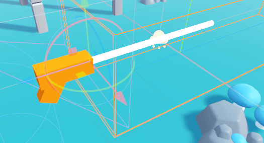

```
export var camera_ray_path: NodePath

onready var _camera_ray: RayCast = get_node(camera_ray_path)
onready var _model: Spatial = $Model
onready var _beam_mesh: Spatial = $Model/BeamMesh
onready var _collision_particles: Particles = $CollisionParticles
onready var _beam_particles: Particles = $Model/BeamParticles
```

We can check if the player is holding the shoot button. If so, make the relevant particles visible, and reveal our beam.

```
func _physics_process(_delta: float) -> void:
    _camera_ray.force_raycast_update()

    var is_firing := Input.is_action_pressed("shoot_3d")
    _collision_particles.emitting = is_firing
    _beam_particles.emitting = is_firing
    _beam_mesh.visible = is_firing

    if not is_firing:
        return
```

Now we can do some collision detection for our beam. If we hit an enemy, call a method on them to take damage and save the position the ray collides with to update the shape of our beam. Otherwise, use the beam’s `cast_to` property to reset its appearance.

We also want to save the normal of the collision point to orient particles to bounce off the surface we hit realistically.

```
    var target: Vector3
    var direction: Vector3
    if _camera_ray.is_colliding():
        var body = _camera_ray.get_collider()
        if body.has_method("take_damage"):
            body.take_damage()
        target = _camera_ray.get_collision_point()
        direction = target + _camera_ray.get_collision_normal()
    else:
        target = _camera_ray.to_global(_camera_ray.cast_to)
        direction = global_transform.origin
    _cast_beam(target, direction)
```

There are two sets of particles, one along the beam and another at the collision point.

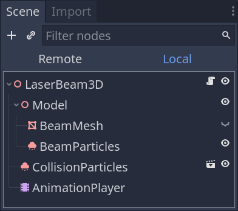

We store the distance from the beam to the target so our mesh and beam particles can have the right length.

We point our beam at the target with the `look_at` function, then set its z scale equal to the distance. Our beam particles are a child of this, so they also scale to match.

```
func _cast_beam(target: Vector3, direction: Vector3) -> void:
    var distance = _model.global_transform.origin.distance_to(target)
    _model.look_at(target, Vector3.UP)
    _model.scale.z = distance
    _collision_particles.global_transform.origin = target
    _collision_particles.look_at(direction, global_transform.basis.z)
```

### Hit-scan bullets

When making 3D guns, you have two choices with your weapons - firing physical projectiles with travel time that can be dodged and hit-scan weapons that instantly hit their targets.

In single-player games, it can feel more accurate to have your player’s weapons be hit-scan. Then if enemy projectiles are physical, they are easier to dodge and less punishing.

[figure not shown]

*Game: Doom (1993)*

Creating a hit-scan weapon is a breeze, thanks to the `RayCast` node.

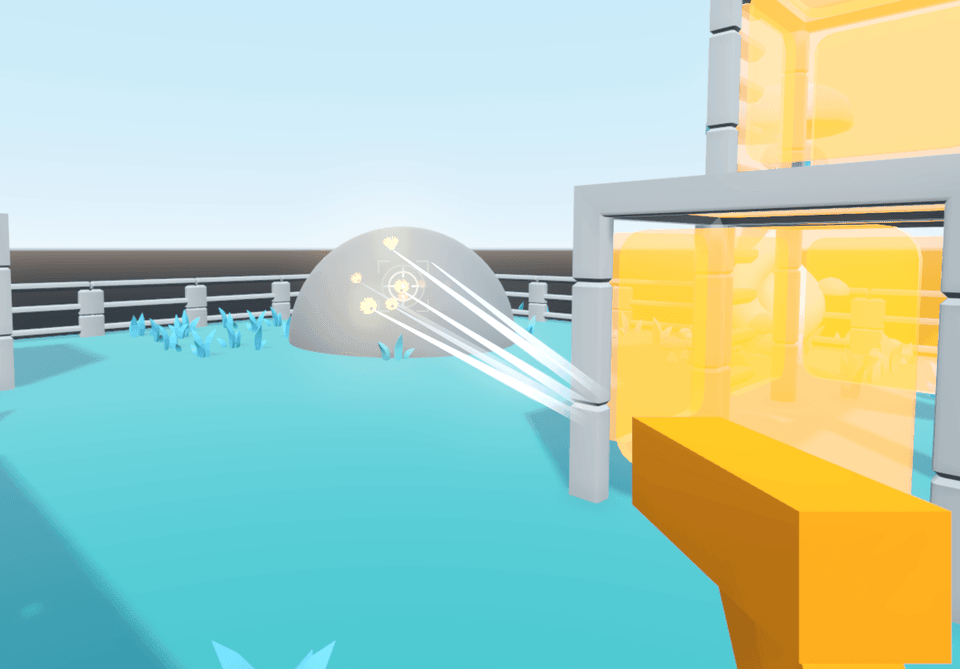

```
export var spray_scene: PackedScene
export var raycast_path: NodePath

var spray_angle_range := 5.0
var min_range := 9.0
var max_range := 12.0

onready var _timer: Timer = $Timer
onready var _ray: RayCast = get_node(raycast_path)
```

Our weapon is automatic, so we need a timer to cool down between shots. When the player holds the shoot button, we call the `shoot_function`. If the timer `is_stopped()`, the gun can fire, and we need to start the timer.

Our weapon has some recoil, so we slightly randomize the angle of the ray, then we instance a bullet scene.

```
func _process(_delta: float) -> void:
    if Input.is_action_pressed("shoot_3d"):
        shoot()

func shoot() -> void:
    if not _timer.is_stopped():
        return

    _timer.start()

    var shoot_vector: Vector3 = Vector3.FORWARD * rand_range(min_range, max_range)
    shoot_vector = shoot_vector.rotated(Vector3.RIGHT, rand_range(0.0, deg2rad(spray_angle_range)))
    shoot_vector = shoot_vector.rotated(Vector3.FORWARD, rand_range(0.0, TAU))
```

Now we check if our ray collides with a target. If so, we tell our bullet scene where the collision occurred and call the hit function for some particles to spawn at the destination. The setup draws a line from our barrel to where the collision occurred that quickly fades out.

If no collision occurs, we draw our line the entire length of the ray instead.

```
    var spray = spray_scene.instance()

    add_child(spray)
    _ray.cast_to = shoot_vector
    _ray.force_raycast_update()
    if _ray.is_colliding():
        spray.setup(global_transform.origin, _ray.get_collision_point())
        spray.hit(
            _ray.get_collision_point(),
            _ray.get_collision_normal(),
            (_ray.get_collision_point() - _ray.global_transform.origin).normalized()
        )
    else:
        spray.setup(global_transform.origin, _ray.to_global(shoot_vector))
```

If a hit occurs, we use the surface’s normal to orient the bullet spray correctly.

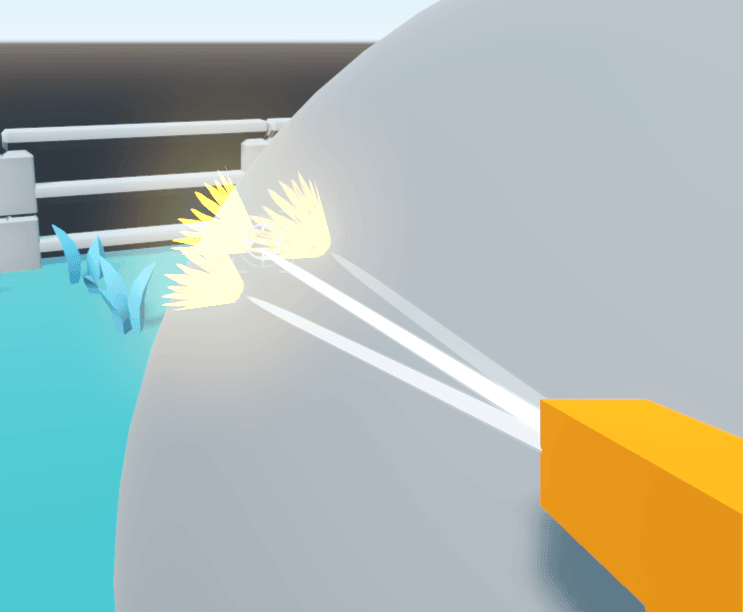

Within the spray scene, it handles the animation for particles and the line mesh fading out.

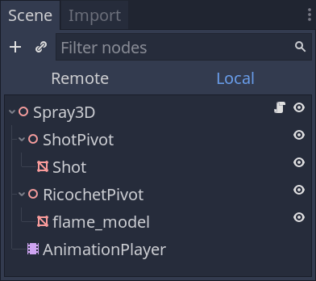

```
onready var _animator: AnimationPlayer = $AnimationPlayer
onready var _shot_pivot: Spatial = $ShotPivot
onready var _ricochet_pivot: Spatial = $RicochetPivot


func _ready() -> void:
    set_as_toplevel(true)
    _ricochet_pivot.visible = false


func setup(origin: Vector3, target: Vector3) -> void:
    if not is_inside_tree():
        yield(self, "ready")
    _shot_pivot.global_transform.origin = origin
    _shot_pivot.look_at(target, Vector3.UP)
    _shot_pivot.scale.z = origin.distance_to(target)
    _animator.play("shoot")


func hit(collision_point: Vector3, collision_normal: Vector3, shot_normal: Vector3) -> void:
    _ricochet_pivot.visible = true
    _ricochet_pivot.global_transform.origin = collision_point
    _ricochet_pivot.look_at(collision_point + collision_normal, shot_normal.cross(collision_normal))
```

## Your questions

### How can I check how close a ray is to pointing at something?

With vector maths checking the similarity of two vectors is a common problem, and the `dot()` function is the solution. This mathematical function compares two vectors and returns a number between `1.0` and negative `1.0`, showing their similarity.

So if you want to trigger an event when a turret is roughly looking at the player, you can take the ray from the turret and use the dot product on the player’s relative position.

If the value is closer to `1.0`, the two vectors are close to being identical. Around `0.0`, the vectors are perpendicular, and at -`1.0`, the vectors are facing opposite directions.

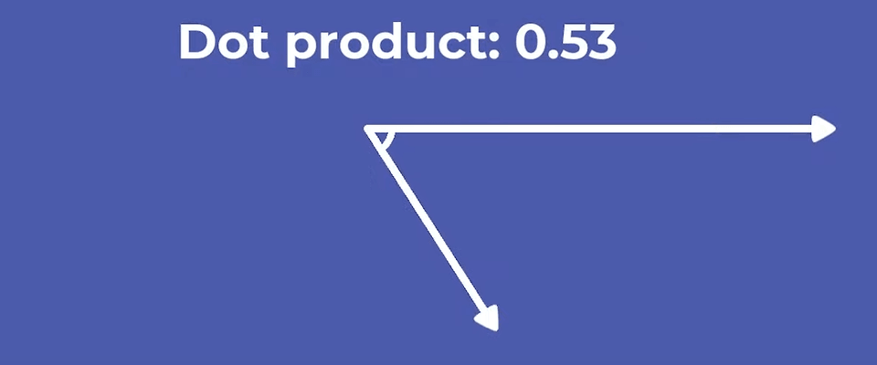

### Reacting to certain collisions

If you want to react to a collision with a specific body, there are a few strategies you can use to check which body you collided with specifically:

- Type checking.
- Checking if it belongs to a group.
- Checking if the body has a given method or property, also known as duck-typing.
- Checking for child nodes.

We detailed those strategies and their pros and cons in the `Area` guide: telling-bodies-apart